# The True Jellyfish (Scyphozoa): Do they matter?

Shin M. Jean F10632016

December 31, 2022

### Materials and Methods

#### **1. Data**

Data was downloaded from a public open access database (IMOS), and randomly selected the area and class on the website’s interactive map.

| survey_id | country | area | realm | location | site_code | latitude | longitude | survey_date | depth | order | family | species_name | size_class | total |
| --- | --- | --- | --- | --- | --- | --- | --- | --- | --- | --- | --- | --- | --- | --- |
| 2001181 | Australia | New South Wales | Temperate Australasia | Sydney | SYD30 | -33.84 | 151.25 | 2009-03-28T00:00:00Z | 1.5 | Semaeostomeae | Ulmaridae | Aurelia aurita | 7.5 | 2 |
| 2001181 | Australia | New South Wales | Temperate Australasia | Sydney | SYD30 | -33.84 | 151.25 | 2009-03-28T00:00:00Z | 1.5 | Semaeostomeae | Ulmaridae | Aurelia aurita | 10 | 1 |
| 6002330 | Australia | Western Australia | Temperate Australasia | Marmion | WA38 | -31.87 | 115.75 | 2009-02-10T00:00:00Z | 4 | Semaeostomeae | Ulmaridae | Aurelia aurita | 7.5 | 1 |
| 6002331 | Australia | Western Australia | Temperate Australasia | Perth Metro | WA36 | -32.01 | 115.78 | 2008-05-17T00:00:00Z | 3 | Rhizostomeae | Mastigiidae | Phyllorhiza punctata | 5 | 1 |
| 6002331 | Australia | Western Australia | Temperate Australasia | Perth Metro | WA36 | -32.01 | 115.78 | 2008-05-17T00:00:00Z | 3 | Rhizostomeae | Mastigiidae | Phyllorhiza punctata | 10 | 1 |
| 6002331 | Australia | Western Australia | Temperate Australasia | Perth Metro | WA36 | -32.01 | 115.78 | 2008-05-17T00:00:00Z | 3 | Rhizostomeae | Mastigiidae | Phyllorhiza punctata | 5 | 10 |
| 6002331 | Australia | Western Australia | Temperate Australasia | Perth Metro | WA36 | -32.01 | 115.78 | 2008-05-17T00:00:00Z | 3 | Rhizostomeae | Mastigiidae | Phyllorhiza punctata | 10 | 10 |
| 6002331 | Australia | Western Australia | Temperate Australasia | Perth Metro | WA36 | -32.01 | 115.78 | 2008-05-17T00:00:00Z | 3 | Rhizostomeae | Mastigiidae | Phyllorhiza punctata | 12.5 | 1 |
| 6002331 | Australia | Western Australia | Temperate Australasia | Perth Metro | WA36 | -32.01 | 115.78 | 2008-05-17T00:00:00Z | 3 | Rhizostomeae | Mastigiidae | Phyllorhiza punctata | 20 | 1 |
| 6002331 | Australia | Western Australia | Temperate Australasia | Perth Metro | WA36 | -32.01 | 115.78 | 2008-05-17T00:00:00Z | 3 | Semaeostomeae | Ulmaridae | Aurelia aurita | 7.5 | 2 |

[output cut: 52 more lines]

Table 1. Data extracted from an open-access live database (Edgar & Stuart-Smith,2014; IMOS).

| latitude | longitude | date | max_temp | min_temp |
| --- | --- | --- | --- | --- |
| -43.25 | 147.25 | 2008-01-01 | 16 | 15 |
| -43.25 | 147.25 | 2008-01-02 | 20.2 | 11.8 |
| -43.25 | 147.25 | 2008-01-03 | 19.7 | 10.9 |
| -43.25 | 147.25 | 2008-01-04 | 26.1 | 11.4 |
| -43.25 | 147.25 | 2008-01-05 | 29.8 | 15.6 |
| -43.25 | 147.25 | 2008-01-06 | 21.5 | 15.8 |
| -43.25 | 147.25 | 2008-01-07 | 23.8 | 10.9 |
| -43.25 | 147.25 | 2008-01-08 | 21.9 | 13.2 |
| -43.25 | 147.25 | 2008-01-09 | 20.1 | 11.7 |
| -43.25 | 147.25 | 2008-01-10 | 28.3 | 14.1 |

[output cut: 5103 more lines]

Table 2. Data extracted from an open access live database for Derwent, TAS (SILO)

| latitude | longitude | date | max_temp | min_temp |
| --- | --- | --- | --- | --- |
| -31.95 | 115.75 | 2008-01-01 | 32.6 | 16.1 |
| -31.95 | 115.75 | 2008-01-02 | 33.9 | 19.4 |
| -31.95 | 115.75 | 2008-01-03 | 38.5 | 23.7 |
| -31.95 | 115.75 | 2008-01-04 | 29.2 | 20.5 |
| -31.95 | 115.75 | 2008-01-05 | 25.3 | 15.3 |
| -31.95 | 115.75 | 2008-01-06 | 28.9 | 17.2 |
| -31.95 | 115.75 | 2008-01-07 | 36.4 | 19.4 |
| -31.95 | 115.75 | 2008-01-08 | 28.6 | 22.5 |
| -31.95 | 115.75 | 2008-01-09 | 25.1 | 19.4 |
| -31.95 | 115.75 | 2008-01-10 | 23.7 | 17 |

[output cut: 5103 more lines]

Table 3. Data extracted from an open access live database for Perth Metro, AUS (SILO)

| latitude | longitude | date | max_temp | min_temp |
| --- | --- | --- | --- | --- |
| -38.1 | 144.7 | 2008-01-01 | 36.7 | 22.8 |
| -38.1 | 144.7 | 2008-01-02 | 20.5 | 15.7 |
| -38.1 | 144.7 | 2008-01-03 | 25.3 | 16.5 |
| -38.1 | 144.7 | 2008-01-04 | 31.4 | 17.7 |
| -38.1 | 144.7 | 2008-01-05 | 34.1 | 20.2 |
| -38.1 | 144.7 | 2008-01-06 | 21.8 | 19.6 |
| -38.1 | 144.7 | 2008-01-07 | 20.9 | 12.2 |
| -38.1 | 144.7 | 2008-01-08 | 21.3 | 15 |
| -38.1 | 144.7 | 2008-01-09 | 24.1 | 16.6 |
| -38.1 | 144.7 | 2008-01-10 | 37.5 | 14.5 |

[output cut: 5103 more lines]

Table 3. Data extracted from an open access live database for Port Phillip Bay, AUS (SILO)

#### **2. Size class and areas where different species are found and surveyed**

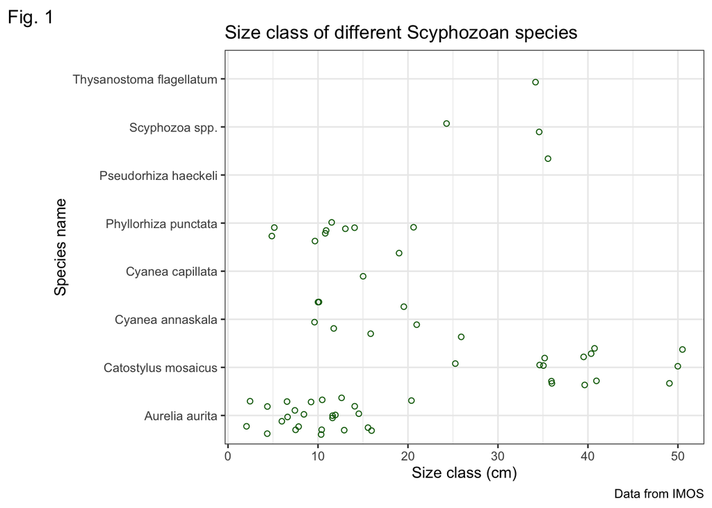

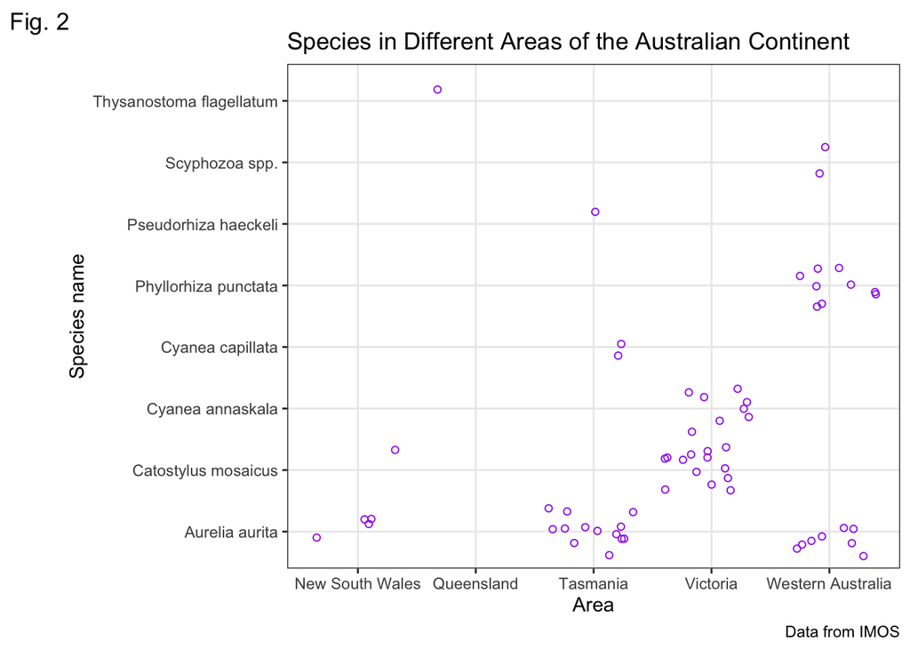

```
##
##                     Aurelia aurita Catostylus mosaicus Cyanea annaskala
##   New South Wales                4                   1                0
##   Queensland                     0                   0                0
##   Tasmania                      13                   0                0
##   Victoria                       0                  13                8
##   Western Australia              8                   0                0
##
##                     Cyanea capillata Phyllorhiza punctata Pseudorhiza haeckeli
##   New South Wales                  0                    0                    0
##   Queensland                       0                    0                    0
##   Tasmania                         2                    0                    1
##   Victoria                         0                    0                    0
##   Western Australia                0                    9                    0
##
##                     Scyphozoa spp. Thysanostoma flagellatum
##   New South Wales                0                        0
##   Queensland                     0                        1
##   Tasmania                       0                        0
##   Victoria                       0                        0
##   Western Australia              2                        0
```

Table 3. Number of species surveyed in each area

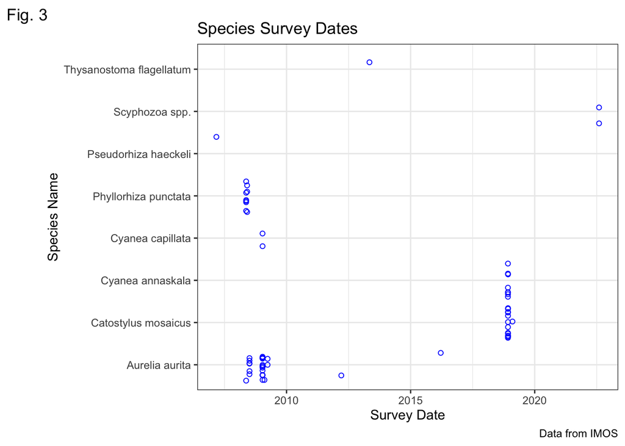

#### **4. Maximum and minimum temperatures**

#### **Derwent, TAS**

[figure not shown]

#### **Perth Metro, AUS**

[figure not shown]

#### **Port Phillip Bay, AUS**

[figure not shown]

#### **3. Plotting and Mapping Software**

I used R studio (ver 22.10.0 for mac) with packages (readxl, tidyr, dplyr, reactable, ggplot2, leaflet) in creating tables, plots, and the interactive map.

### Results

#### **1. Interactive map of different Scyphozoan species and their survey locations**

[interactive chart not shown]

Map 1. Map of Australia with interactive popups for species name.

This is the interactive map created using the leaflet package, where popups show the species name surveyed from each location. Different species of Scyphozoa are scattered around the coastlines of Australia, but *Aurelia aurita* is the most commonly observed species all over the continent, with *Catostylus mosaicus* following with 14 observations. Most of the observations for *A. aurita* were from Tasmania, while *C. mosaicus* were observed in Victoria, AUS.

#### **2. Survey dates and size class of Scyphozoan species**

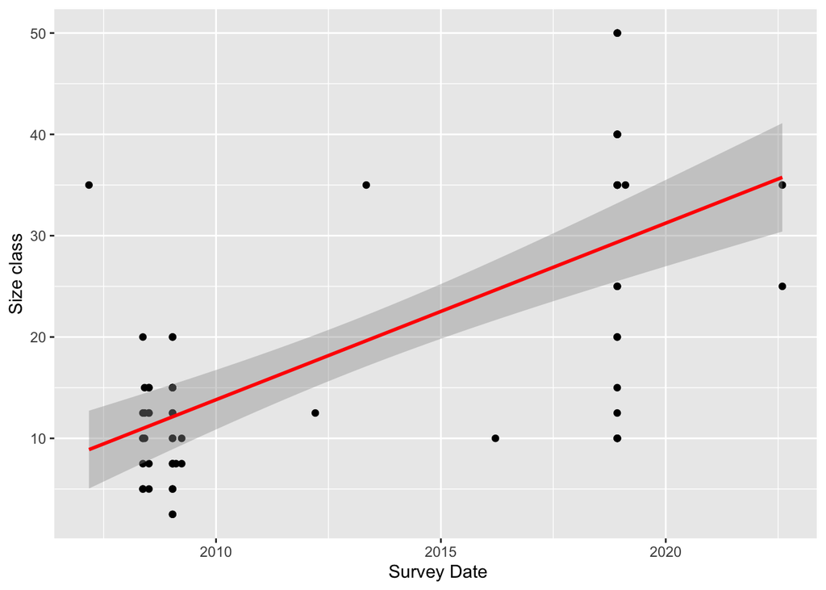

#### **3. Jellyfish, temperature, and humans**

According to Purcell et al., 2013, these organisms can disrupt human livelihood especially in the fishing industry, destroying net pens and cause fish gill disorders. Australia’s climate usually ranges from hot-dry or hot-humid summer to warm winters (SILO). True jellyfish possess tentacles with stingers that usually contains venom, and may cause serious human health issues if not treated properly. The Australian climate could play a huge factor in the frequent appearance of Rhizostome jellyfish (Kramp, 1961). As people go to the coastlines or beaches for leisure, the appearance of Scyphozoa in the summer will be more apparent.a

### Discussion

The data presented is limited for this study, the true jellyfish, Scyphozoa. The data entails the size, location, and date for the population. If the survey was to be done on a monthly basis, the data presented would be more reliable and dependable. With the rise of temperature, there would be a correlated growth of the species. On the other hand, with the rise of temperature, there is no apparent survey that discusses the growth of the jellyfish. The growth of such species would take at most 5 years for data to be reliable and sufficient. Furthermore, for human safety, learning about such species would be of relevance. When children and adult are in vacation or enjoying their time, danger can always be around the corner. For one to understand more about the species and how to treat its sting, further studies should be conducted. Human safety is always one’s top priority.

### References

Cartwright, P., Halgedahl, S. L., Hendricks, J. R., Jarrard, R. D., Marques, A. C., Collins, A. G., & Lieberman, B. S. (2007). Exceptionally Preserved Jellyfishes from the Middle Cambrian. PLoS One, 2(10), e1121. https://doi.org/10.1371/journal.pone.0001121

Cruz-Rivera, E., & El-Regal, M. A. (2016). A bloom of an edible scyphozoan jellyfish in the Red Sea. Marine Biodiversity, 46(2), 515-519. https://doi.org/10.1007/s12526-015-0381-1

Kramp, P. L. (1961). Synopsis of the Medusae of the World. Journal of the Marine Biological Association of the United Kingdom, 40, 7-382. https://doi.org/10.1017/S0025315400007347

Purcell, J. E., Baxter, E. J., & Fuentes, V. L. (2013). 13 - Jellyfish as products and problems of aquaculture. In G. Allan & G. Burnell (Eds.), Advances in Aquaculture Hatchery Technology (pp. 404-430). Woodhead Publishing. https://doi.org/https://doi.org/10.1533/9780857097460.2.404

SILO,Australian climate data from 1889 to yesterday, Queensland Government, https://www.longpaddock.qld.gov.au/silo/point-data/

Remigante, A., Costa, R., Morabito, R., La Spada, G., Marino, A., & Dossena, S. (2018). Impact of Scyphozoan Venoms on Human Health and Current First Aid Options for Stings. Toxins, 10(4), 133. https://doi.org/10.3390/toxins10040133